# Tutorial 4

# Libraries

```r
library(dplyr)
library(smacof)
library(cmdpref)
library(ggplot2)
```

# Question 2

- Small number is similar, large is different
- Can straight away use this dataset to `mds()` function

```r
load(file='/Users/jasonchan/MSTAT/STAT8019_Marketing_Analytics/tutorial notes/t4/TUT04.RData')
```

```r
head(b2b)
```

```
        Poland Sweden Germany USA France Italy South.Africa Brazil
Poland     0.0     NA      NA  NA     NA    NA           NA     NA
Sweden     2.0    0.0      NA  NA     NA    NA           NA     NA
Germany    8.0    3.5     0.0  NA     NA    NA           NA     NA
USA       13.0   11.0     3.5   0     NA    NA           NA     NA
France    20.0   17.0    14.5  10      0    NA           NA     NA
Italy     32.5   26.0    18.0  16      6     0           NA     NA
        China Japan
Poland     NA    NA
Sweden     NA    NA
Germany    NA    NA
USA        NA    NA
France     NA    NA
Italy      NA    NA
```

## Part (a)

Available scales are `"ratio", "interval", "ordinal", "mspline".`

- Dataset is ranked, so use “ordinal” (nonmetric MDS)

## Part (b)

```r
fit1 <- mds(b2b, ndim = 1, type = "ordinal")

fit1
```

```
Call:
mds(delta = b2b, ndim = 1, type = "ordinal")

Model: Symmetric SMACOF
Number of objects: 10
Stress-1 value: 0.304
Number of iterations: 10
```

```r
fit2 <- mds(b2b, ndim = 2, type = "ordinal")

fit2
```

```
Call:
mds(delta = b2b, ndim = 2, type = "ordinal")

Model: Symmetric SMACOF
Number of objects: 10
Stress-1 value: 0.002
Number of iterations: 21
```

```r
fit3 <- mds(b2b, ndim = 3, type = "ordinal")

fit3
```

```
Call:
mds(delta = b2b, ndim = 3, type = "ordinal")

Model: Symmetric SMACOF
Number of objects: 10
Stress-1 value: 0.004
Number of iterations: 31
```

- 2-dimensions have the lowest stress

## Part (c)

Perceptual map

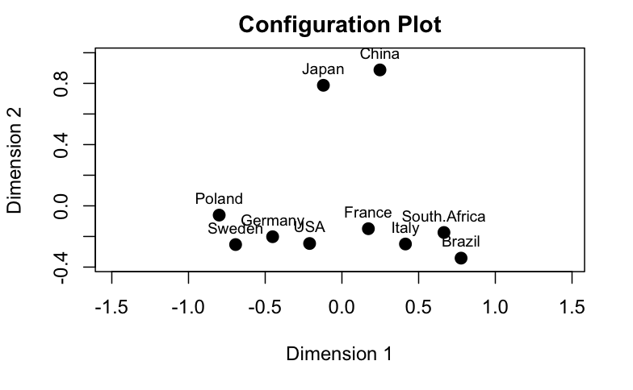

```r
plot(fit2, cex=2)
```

## Part (d)

- Differences of asian and western customers
- Dimension 2 separates the **asian and western countries**
- Dimension 1 separates the **northern and southern hemisphere**, culture of the countries

```r
fit2$conf
```

```
                     D1          D2
Poland       -0.8000034 -0.06050837
Sweden       -0.6930320 -0.25291695
Germany      -0.4517310 -0.20166553
USA          -0.2106696 -0.24592708
France        0.1724629 -0.14935441
Italy         0.4140936 -0.24923931
South.Africa  0.6651428 -0.17402573
Brazil        0.7766837 -0.34155333
China         0.2478863  0.88779078
Japan        -0.1208332  0.78739993
```

## Cluster Analysis

- `b2b` can also be treated as a distance matrix
- apply `hclust` to it

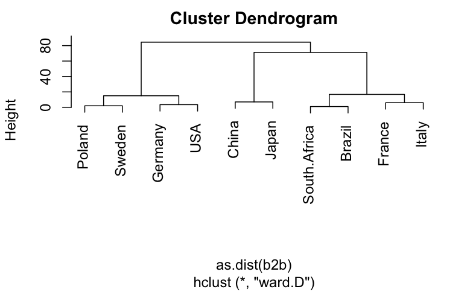

```r
fit <- hclust(as.dist(b2b), method = 'ward.D')
plot(fit)
```

- can first use mds to visualize map
- then use hclust
- hclust only give grouping but mds give direction and visualize in map

# Question 3

- MDS unfolding model means *Multidimensional Scaling Preference (MDPREF)* model

```r
crisps<-read.csv("/Users/jasonchan/MSTAT/STAT8019_Marketing_Analytics/tutorial notes/t4/TUT07.csv", header = TRUE,row.names = 1)
head(crisps)
```

|  | Crisp1 | Crisp2 | Crisp3 | Crisp4 | Crisp5 | Crisp6 | Crisp7 | Crisp8 | Crisp9 | Crisp10 |
| --- | --- | --- | --- | --- | --- | --- | --- | --- | --- | --- |
| 1 | 7 | 6 | 2 | 7 | 26 | 21 | 11 | 4 | 29 | 9 |
| 2 | 0 | 0 | 22 | 26 | 0 | 29 | 5 | 27 | 5 | 25 |
| 3 | 6 | 27 | 10 | 0 | 0 | 21 | 27 | 4 | 11 | 27 |
| 4 | 29 | 0 | 0 | 29 | 26 | 0 | 29 | 0 | 19 | 29 |
| 5 | 11 | 22 | 5 | 0 | 0 | 14 | 27 | 26 | 24 | 26 |
| 6 | 27 | 29 | 6 | 0 | 26 | 14 | 4 | 27 | 29 | 7 |

## Part (a)

- Using metric MDS

```r
crisps <- t(crisps)
```

```r
fit5 <- cmdpref(crisps, ndim = 9)
summary(fit5)
```

```
Object coordinates
           dim1    dim2    dim3    dim4    dim5    dim6    dim7
Crisp1  -0.5393 -0.6240  0.6479 -0.1752 -1.2890  1.0629 -1.9933
Crisp2  -0.0393  1.8970 -0.2378  0.4495 -0.2282 -0.1124 -0.3494
Crisp3   1.7355 -0.0392  0.8055 -0.3419  1.1226  1.1506  0.4256
Crisp4   1.4526 -1.0259 -0.7740 -0.9690 -0.1031 -1.1343 -0.6220
Crisp5  -0.9494 -0.2790  1.6731 -0.4356  0.3256 -1.8533  0.3155
Crisp6   0.5196  1.5387 -0.5383 -0.1051 -0.7839 -0.5925  0.0947
Crisp7   0.0857 -0.2058  1.1653  0.9689 -0.6740  0.7073  1.2416
Crisp8  -1.4066  0.1231 -0.8113 -1.8569  0.5555  0.9687  0.7694
Crisp9  -0.2567 -1.1906 -1.3574  1.0263 -0.8689 -0.1409  1.0806
Crisp10 -0.6021 -0.1943 -0.5729  1.4389  1.9435 -0.0561 -0.9627
           dim8    dim9
Crisp1   0.4479  0.0643
Crisp2  -1.0830  1.6975
```

[output cut: 222 more lines]

- Using 2 dimensions explains 42.9% of variation
- Using 5 dimensions explains 72% of variation

## Part (b)

- Using non metric MDS, set `monotone=T`
- Ordinal scale, rank data
- 2 dimensions assumed

### (i)

```r
fit2 <- cmdpref(crisps, monotone = T)
```

```
[1] "convergence not met"
```

```r
summary(fit2)
```

```
Object coordinates
           dim1    dim2
Crisp1  -0.4046  0.2548
Crisp2  -0.1419 -1.9396
Crisp3   1.9859  0.1868
Crisp4   1.5470  0.8478
Crisp5  -0.6447  0.5698
Crisp6   0.2629 -1.7667
Crisp7  -0.3641  0.5644
Crisp8  -1.0463  0.2188
Crisp9  -0.4329  0.6748
Crisp10 -0.7613  0.3891

Subject vectors
      dim1    dim2
```

[output cut: 106 more lines]

- Monotine using 2 dim explains 64% of variance

### (ii)

```r
fit2$score
```

```
              dim1       dim2
Crisp1  -0.4046377  0.2547869
Crisp2  -0.1418663 -1.9396211
Crisp3   1.9859432  0.1867883
Crisp4   1.5469653  0.8478362
Crisp5  -0.6447084  0.5697988
Crisp6   0.2628917 -1.7667347
Crisp7  -0.3641009  0.5644141
Crisp8  -1.0463171  0.2187956
Crisp9  -0.4328601  0.6747981
Crisp10 -0.7613097  0.3891377
```

```r
head(fit2$corr)
```

```
         dim1       dim2
1 -0.72822180  0.0117155
2  0.09237073 -0.6207673
3 -0.25508485 -0.6084227
4 -0.22821587  0.7102130
5 -0.66001174 -0.3870949
6 -0.75705144 -0.3882459
```

### (iii)

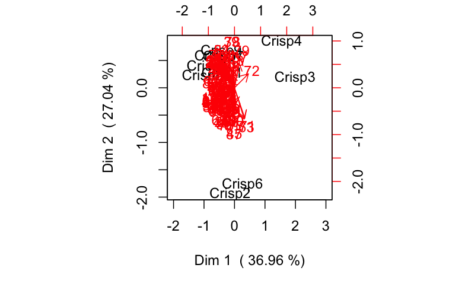

```r
plot(fit2, xlim=c(-2,3))
```

- No clear goruping of consumers but there are for crisps
- Crisp 2 and 6 are competing
- Crisp 4 and 3 are competing
- Others are clustered

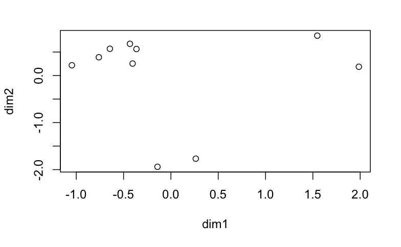

```r
plot(fit2$score)
```